# The illusion of predictability in common scientific visualizations, data scientists

2023-05-20

# 1 Loading data

We have four datasets: * `-tidy-background.csv` contains the background information for each participant. * `-tidy-psup-game.csv` contains information on each trial of the psup game. * `-tidy-editorial.csv` contains the last trial for which we have data on each participant, and the corresponding editorial data thus far * `-tidy-elapsed.csv` contains the timing data for each stage and trial

## 1.1 Background questions

As preregistered, we drop people who do not answer yes to any of the background questions or meet the other inclusion criteria. How many people would we drop?

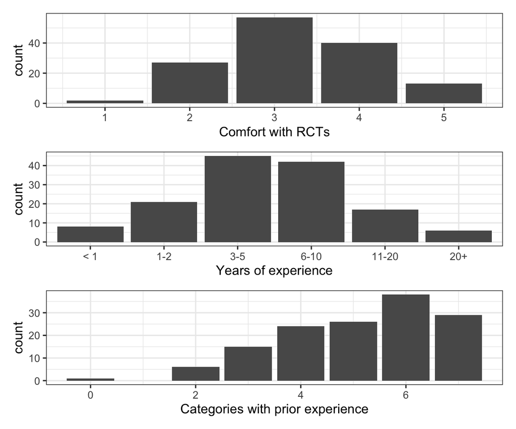

```r
background_ds <- read_ds_bg()

assignments_to_drop1 = background_ds %>%
  filter((has_any_stats_training == 0) | (rctComfort == 1)) %>%
  select(assignmentId)

background_with_number_done <- background_ds %>%
  rename(is_phd=has_phd) %>%  # the has_ variables are part of the "past activities" question, except for has_phd
  select(assignmentId, starts_with("has_")) %>%
  mutate(across(starts_with("has_"), as.logical)) %>%
  mutate(across(starts_with("has_"), as.integer)) %>%
  rowwise() %>%
  mutate(number_done = sum(across(starts_with("has_"))))

bg.rct <- ggplot(background_ds, aes(x=rctComfort)) +
  geom_bar() +
  xlab("Comfort with RCTs")

bg.yrs.experience <- background_ds %>%
  mutate(yearsExperience=recode_factor(yearsExperience,
                                       "Less than 1 year"="< 1",
                                       "1-2 years"="1-2",
                                       "3-5 years"="3-5",
                                       "6-10 years"="6-10",
                                       "11-20 years"="11-20",
                                       "20+ years"="20+")) %>%
  ggplot(aes(x=yearsExperience)) +
  xlab("Years of experience") +
  geom_bar()

bg.number.done <- ggplot(background_with_number_done, aes(x=number_done)) +
  xlab("Categories with prior experience") +
  geom_bar()

bg.rct / bg.yrs.experience / bg.number.done
```

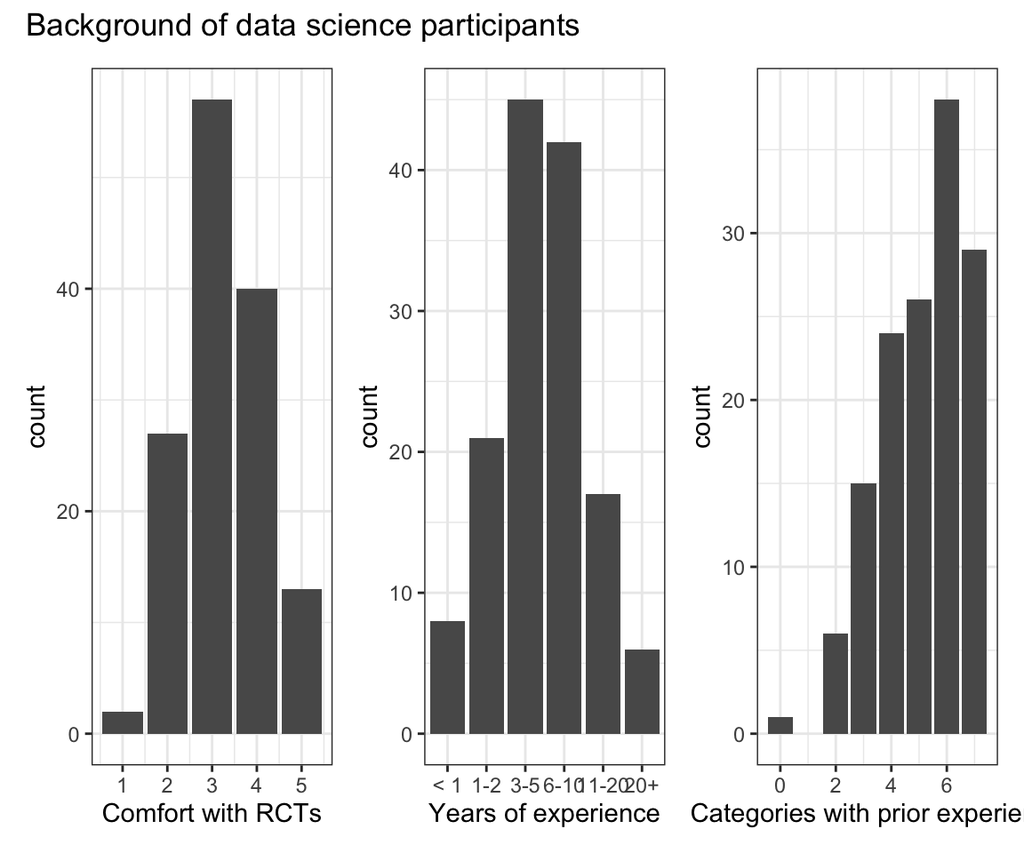

```r
ggsave(here(paste("analysis/figures/", experiment, "-background.pdf", sep="")), width=4, height=6)

bg.rct + bg.yrs.experience + bg.number.done +
  plot_annotation(title = "Background of data science participants")
```

```r
ggsave(here(paste("analysis/figures/", experiment, "-background-wide.pdf", sep="")), width=10, height=3)

assignments_to_drop = c(
  background_with_number_done %>%
    filter(number_done == 0) %>% select(assignmentId),
  assignments_to_drop1)

background_numbers = list()
background_numbers["total"] = nrow(background_ds)
background_numbers["num_dropped"] = length(assignments_to_drop)
background_cols = c("has_phd", "has_conducted_rct", "has_published", "has_took_course", "has_analyzed_data", "has_used_stats_software")
for (col in background_cols) {
  background_numbers[col] = sum(as.logical(background_ds[[col]]))
}

assignments_to_drop
```

```
## $assignmentId
## [1] "3ff20ec2-2bfc-4f09-8118-499b423e5dc0"
##
## $assignmentId
## [1] "3ff20ec2-2bfc-4f09-8118-499b423e5dc0"
## [2] "4fccd338-0afa-4bce-b16b-d1dca8179139"
## [3] "94d5d2fd-4978-4a4b-abd1-b861f7a22803"
```

## 1.2 Trial and editorial data

### 1.2.1 Statistical tests

```r
attach(read_ds_data(background_ds))
ds_editorial_test_results <- editorial_tests(datascientist_editorial_data)
attach(ds_editorial_test_results)

ds_editorial_test_results
```

```
## $appeal_t_stats
## [1] "t(168.6) = -1.56, p = .120"
##
## $overall_t_stats
## [1] "t(171.3) = 0.52, p = .604"
##
## $sample_t_stats
## [1] "t(152.9) = -0.88, p = .380"
##
## $paper_psup_extreme_t_stats
## [1] "t(142.5) = 5.11, p < .001"
##
## $paper_psup_extreme_props
## # A tibble: 2 × 3
##   condition   num_extreme prop_extreme
##   <fct>             <int>        <dbl>
## 1 SE Only              33       0.351
## 2 SE + Points           5       0.0625
##
## $paper_psup_t_stats
## [1] "t(159.4) = 6.34, p < .001"
##
## $editorial_psup_summaries
## # A tibble: 2 × 3
##   condition      mu    sd
##   <fct>       <dbl> <dbl>
## 1 SE Only      76.4  19.9
## 2 SE + Points  60.6  12.6
```

### 1.2.2 Editorial judgments

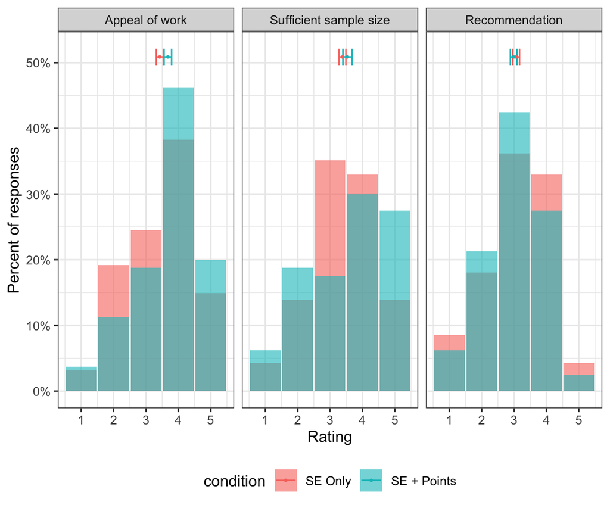

```r
editorial_plot <- plot_editorial_data(datascientist_editorial_data)
editorial_plot
```

```r
ggsave(paste("figures/", experiment, "_editorial_responses_histograms_overlayed.pdf", sep=""), width=7, height=3)
```

### 1.2.3 Probability of superiority judgment for paper

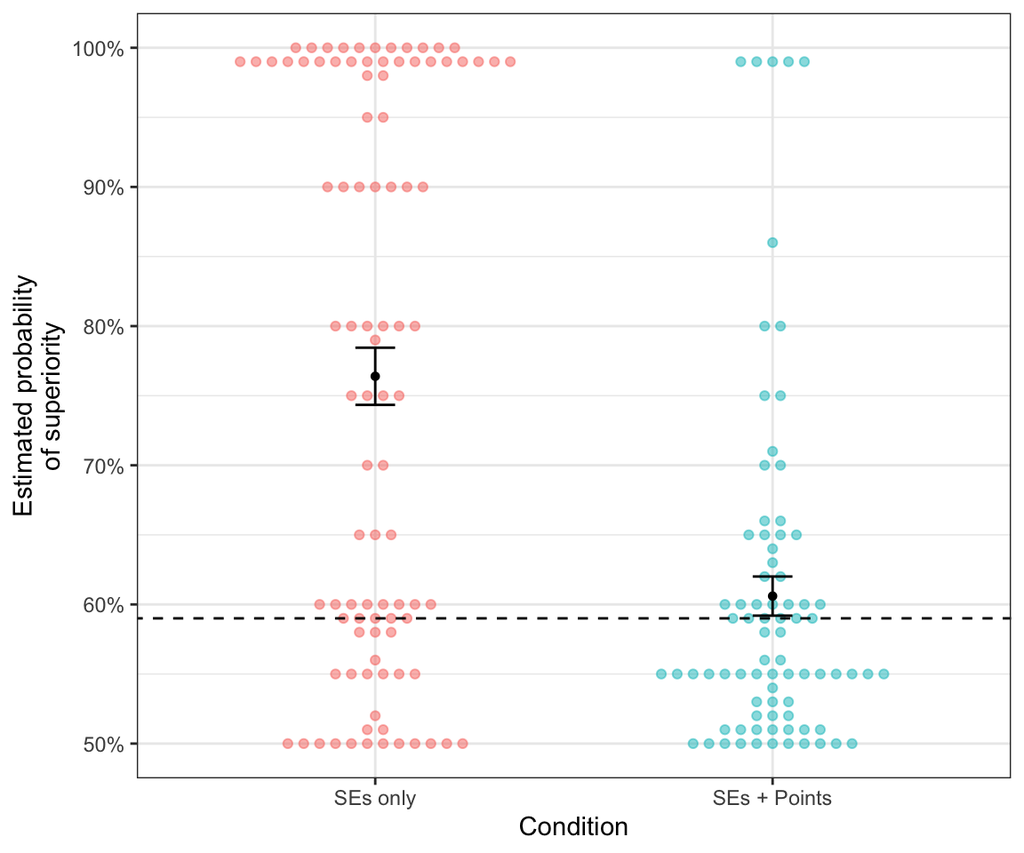

```r
editorial_psup_figure <- plot_editorial_psup(datascientist_editorial_data)
editorial_psup_figure
```

```r
ggsave(paste("./figures/", experiment, "_estimated_psup.pdf", sep=""), width=4, height=4)
```

### 1.2.4 Perceived error bars

What did people think they saw?

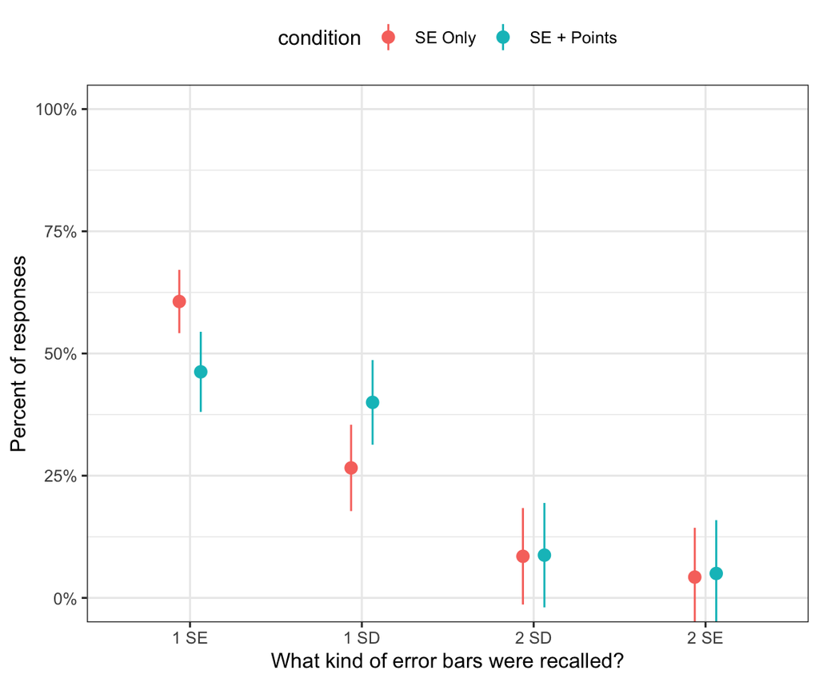

```r
plot_whatYouSaw_q1(datascientist_editorial_data)
```

```r
ggsave(paste("./figures/", experiment, "_recalled_q1.pdf", sep=""), width=4, height=4)
```

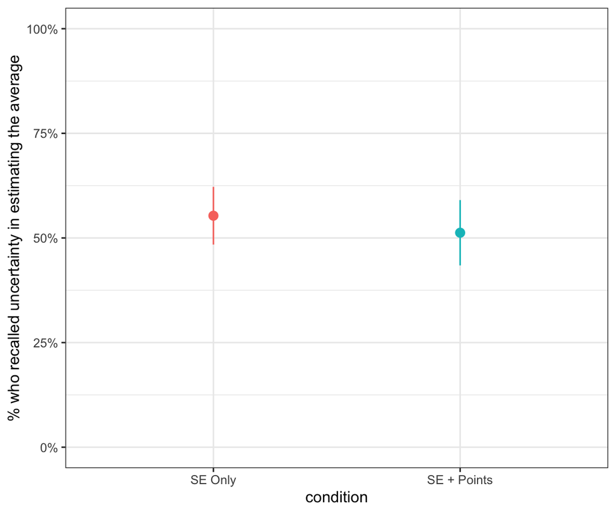

```r
plot_whatYouSaw_q2(datascientist_editorial_data)
```

```r
ggsave(paste("./figures/", experiment, "_recalled_q2.pdf", sep=""), width=4, height=4)

datascience_recalled_q1_env <- recalled_tests_q1(datascientist_editorial_data)
datascience_recalled_q1_env
```

```
## $whatYouSaw
## # A tibble: 8 × 5
## # Groups:   condition [2]
##   condition   paperA_whatYouSaw     n   frac     se
##   <fct>       <fct>             <int>  <dbl>  <dbl>
## 1 SE Only     1 SD                 25 0.266  0.0884
## 2 SE Only     1 SE                 57 0.606  0.0647
## 3 SE Only     2 SD                  8 0.0851 0.0987
## 4 SE Only     2 SE                  4 0.0426 0.101
## 5 SE + Points 1 SD                 32 0.4    0.0866
## 6 SE + Points 1 SE                 37 0.462  0.0820
## 7 SE + Points 2 SD                  7 0.0875 0.107
## 8 SE + Points 2 SE                  4 0.05   0.109
##
## $whatYouSaw_SEvsSD
## # A tibble: 4 × 5
## # Groups:   condition [2]
##   condition   whatYouSaw     n  frac     se
##   <fct>       <fct>      <int> <dbl>  <dbl>
## 1 SE Only     SD            33 0.351 0.0831
## 2 SE Only     SE            61 0.649 0.0611
## 3 SE + Points SD            39 0.488 0.0800
## 4 SE + Points SE            41 0.512 0.0781
```

```r
datascience_recalled_q2_env <- recalled_tests(datascientist_editorial_data)
datascience_recalled_q2_env
```

```
## $recalled_avg_means
## # A tibble: 2 × 5
## # Groups:   condition [2]
##   condition   paperA_whatYouSaw2      n  frac     se
##   <fct>       <chr>               <int> <dbl>  <dbl>
## 1 SE Only     recalled_uncert_avg    52 0.553 0.0689
## 2 SE + Points recalled_uncert_avg    41 0.512 0.0781
##
## $recalled_avg_t_stats
## [1] "t(167.2) = 0.533, p = .594"
```

### 1.2.5 Mediation of overall effect by perceived error bars

If we include the understanding of the error bars as a covariate, can we explain the main effect of condition on the perceived probability of superiority?

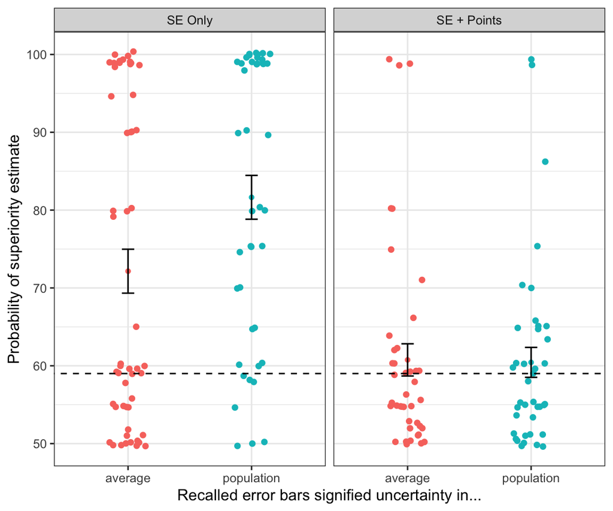

```r
plot_accuracy_vs_recalled(datascientist_editorial_data)
```

```r
ggsave(paste("./figures/", experiment, "_recalled_q2_vs_psup.pdf", sep=""), width=6, height=4)
```

```r
paper_psup_ds <- datascientist_editorial_data %>% filter(!is.na(paperA_superiorityEstimate))
mod.supestimate.mediation <- lm(paperA_superiorityEstimate ~ relevel(as.factor(paperA_whatYouSaw2), ref="recalled_uncert_pop") + condition, paper_psup_ds)
summary(mod.supestimate.mediation)
```

```
##
## Call:
## lm(formula = paperA_superiorityEstimate ~ relevel(as.factor(paperA_whatYouSaw2),
##     ref = "recalled_uncert_pop") + condition, data = paper_psup_ds)
##
## Residuals:
##     Min      1Q  Median      3Q     Max
## -29.133 -13.138  -3.186  15.819  40.814
##
## Coefficients:
##                                                                                        Estimate
## (Intercept)                                                                              79.133
## relevel(as.factor(paperA_whatYouSaw2), ref = "recalled_uncert_pop")recalled_uncert_avg   -4.953
## conditionSE + Points                                                                    -15.995
##                                                                                        Std. Error
## (Intercept)                                                                                 2.238
## relevel(as.factor(paperA_whatYouSaw2), ref = "recalled_uncert_pop")recalled_uncert_avg      2.557
## conditionSE + Points                                                                        2.559
##                                                                                        t value
## (Intercept)                                                                             35.362
## relevel(as.factor(paperA_whatYouSaw2), ref = "recalled_uncert_pop")recalled_uncert_avg  -1.937
## conditionSE + Points                                                                    -6.250
##                                                                                        Pr(>|t|)
## (Intercept)                                                                             < 2e-16
## relevel(as.factor(paperA_whatYouSaw2), ref = "recalled_uncert_pop")recalled_uncert_avg   0.0544
## conditionSE + Points                                                                   3.17e-09
##
## (Intercept)                                                                            ***
## relevel(as.factor(paperA_whatYouSaw2), ref = "recalled_uncert_pop")recalled_uncert_avg .
## conditionSE + Points                                                                   ***
## ---
## Signif. codes:  0 '***' 0.001 '**' 0.01 '*' 0.05 '.' 0.1 ' ' 1
##
## Residual standard error: 16.81 on 171 degrees of freedom
## Multiple R-squared:  0.1968, Adjusted R-squared:  0.1874
## F-statistic: 20.95 on 2 and 171 DF,  p-value: 7.296e-09
```

This suggests that even correct understanding of the error bars leads to biased effect size judgments when only shown inferential uncertainty, and that estimates based off displays using SEs + points are more robust to misunderstandings of the inferential statistics.

Mediation of editorial judgment by perceived probability of superiority:

```r
mod.editorial.mediation.ds <- lm(q_overall ~ paperA_superiorityEstimate + condition, paper_psup_ds)
summary(mod.editorial.mediation.ds)
```

```
##
## Call:
## lm(formula = q_overall ~ paperA_superiorityEstimate + condition,
##     data = paper_psup_ds)
##
## Residuals:
##      Min       1Q   Median       3Q      Max
## -2.28677 -0.64366  0.06329  0.62256  2.22116
##
## Coefficients:
##                            Estimate Std. Error t value Pr(>|t|)
## (Intercept)                1.812137   0.335395   5.403 2.17e-07 ***
## paperA_superiorityEstimate 0.016385   0.004205   3.896  0.00014 ***
## conditionSE + Points       0.182445   0.156905   1.163  0.24654
## ---
## Signif. codes:  0 '***' 0.001 '**' 0.01 '*' 0.05 '.' 0.1 ' ' 1
##
## Residual standard error: 0.9345 on 171 degrees of freedom
## Multiple R-squared:  0.08296,    Adjusted R-squared:  0.07224
## F-statistic: 7.735 on 2 and 171 DF,  p-value: 0.0006083
```

```r
mod.editorial.mediation.bg.ds <- fit_psup_vs_overall_emm_datascientists(background_ds, datascientist_editorial_data)
datascience_mediation_psup_coef <- tidy(coeftest(mod.editorial.mediation.bg.ds, vcov. = vcovCL)) %>%
  filter(term == "paperA_superiorityEstimate")
datascience_mediation_psup_coef
```

```
## # A tibble: 1 × 5
##   term                       estimate std.error statistic p.value
##   <chr>                         <dbl>     <dbl>     <dbl>   <dbl>
## 1 paperA_superiorityEstimate   0.0159   0.00495      3.21 0.00169
```

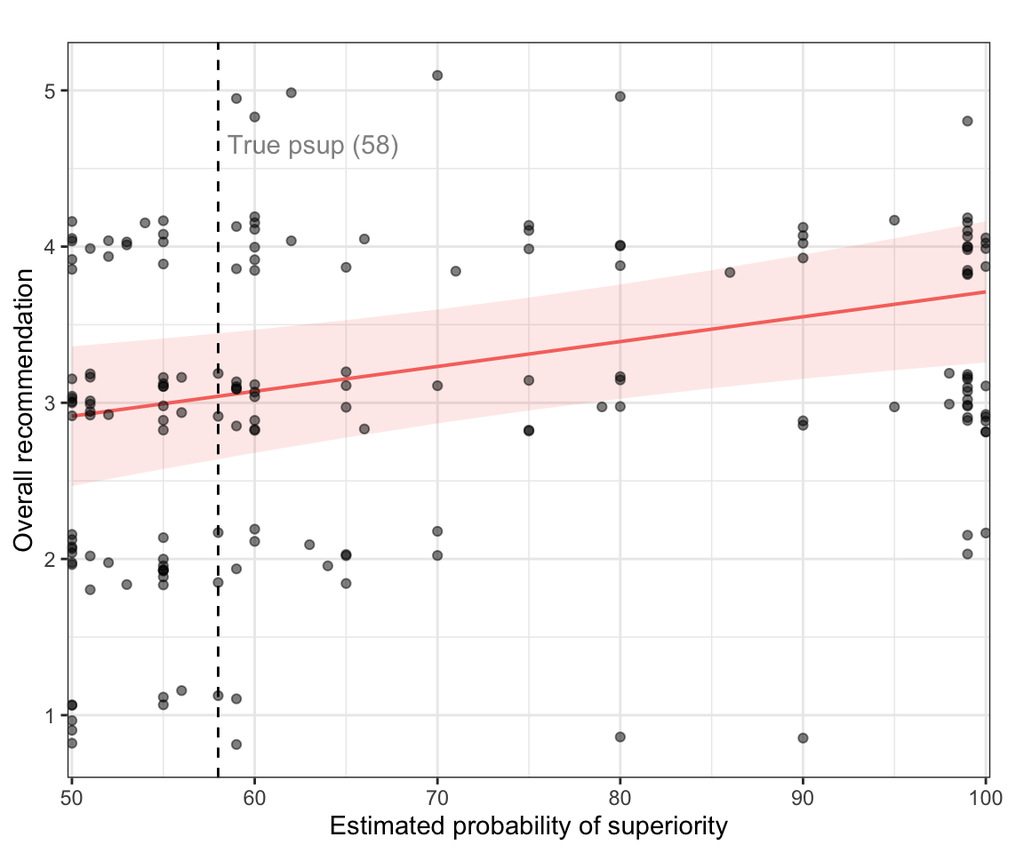

```r
plot_psup_vs_overall_emm(mod.editorial.mediation.bg.ds, datascientist_editorial_data) +
  geom_vline(xintercept=58, linetype="dashed") +
  geom_text(data=data.frame(x=58.5, y=4.6, text="True psup (58)"), aes(x=x,y=y,label=text), alpha=0.5, hjust="left", vjust="bottom")
```

# 2 Part II: Analyses of the psup game

## 2.1 True psup vs. signed error

This is Part II of the experiment, and here we are examining how the guessed probability of superiority varies based on the true probability of superiority.

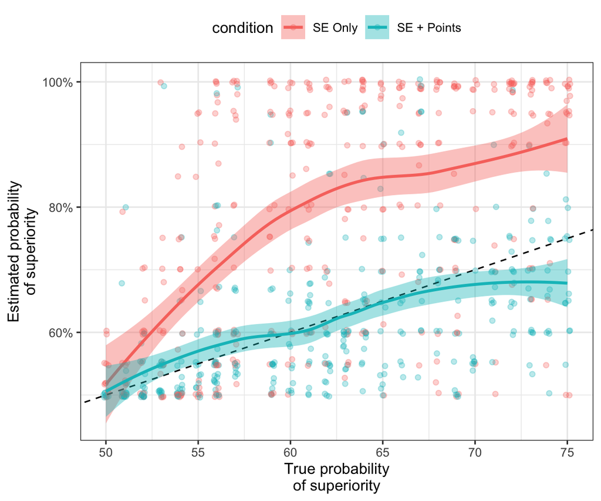

```r
plot_psup_game(datascientist_trials)
```

```r
ggsave(paste("./figures/", experiment, "_psup_game.pdf", sep=""), width=4, height=4)
datascience_test_results <- psup_game_tests(datascientist_trials)
das_trials_extreme_means = datascience_test_results$trials_extreme_means
das_trials_extreme_t_stats = datascience_test_results$trials_extreme_t_stats
das_trials_lmer_coef = datascience_test_results$trials_lmer_coef
attach(datascience_test_results)

datascience_test_results
```

```
## $trials_lmer_coef
## # A tibble: 1 × 4
##   term                           estimate std.error statistic
##   <chr>                             <dbl>     <dbl>     <dbl>
## 1 conditionSE_POINTS_NO_FEEDBACK    -11.0      1.37     -8.03
##
## $trials_extreme_means
## # A tibble: 2 × 4
##   condition             num_extreme prop_extreme count
##   <chr>                       <int>        <dbl> <int>
## 1 SE_NO_FEEDBACK                142       0.374    380
## 2 SE_POINTS_NO_FEEDBACK          13       0.0371   350
##
## $trials_extreme_t_stats
## [1] "$t(500.3) = 12.5$, $p < .001$"
```

# 3 Saving .Rdata for rtex document

```r
das_sample_t_stats = sample_t_stats
das_appeal_t_stats = appeal_t_stats
das_overall_t_stats = overall_t_stats
das_editorial_psup_summaries = editorial_psup_summaries
das_paper_psup_t_stats = paper_psup_t_stats
das_paper_psup_extreme_props = paper_psup_extreme_props
das_paper_psup_extreme_t_stats = paper_psup_extreme_t_stats

datascience_recalled_q1 <- datascience_recalled_q1_env$whatYouSaw
datascience_recalled_q2_means <- datascience_recalled_q2_env$recalled_avg_means
datascience_recalled_q2_t_stats <- datascience_recalled_q2_env$recalled_avg_t_stats
datascience_recalled_q1_one_SE <-  datascience_recalled_q1 %>%
  filter(paperA_whatYouSaw == "1 SE")
datascience_recalled_q1_SEvsSD <- datascience_recalled_q1_env$whatYouSaw_SEvsSD %>% filter(whatYouSaw == "SE")

save(
  background_numbers,
  das_sample_t_stats, das_overall_t_stats, das_appeal_t_stats,
  das_paper_psup_t_stats, das_trials_lmer_coef,
  das_trials_extreme_means, das_trials_extreme_t_stats,
  das_paper_psup_extreme_props, das_paper_psup_extreme_t_stats,
  das_editorial_psup_summaries,
  datascience_recalled_q1_one_SE, datascience_recalled_q2_means,
  datascience_recalled_q1_SEvsSD, datascience_recalled_q2_t_stats,
  datascience_mediation_psup_coef,
  file="results/das_results.Rdata")
```

# 4 Part III: Free response feedback

```r
show_feedback(experiment)
```

| condition | feedback |
| --- | --- |
| SE_POINTS_NO_FEEDBACK | There's an obvious confusion between 1) The average effect that is reported, and the likelihood of an individual exhibiting the outcome from one cohort compared to the other. I presume that's what at … |
| SE_NO_FEEDBACK | It was unclear to me whether you were hoping I’d hazard a guess or find my calculator and consult a CDF table: I tried the latter (but my math might be bad) |
| SE_NO_FEEDBACK | I think the first graph was incorrect. The boxplot lines should have overlapped (mean of 6.8 + s.d. of 0.5 should have spanned 7.3 to 6.3 which included the mean of the other group). Though I'm not su… |
| SE_POINTS_NO_FEEDBACK | I interpreted the last 5 questions as ballpark guesses based on intuition instead of estimating ste and computing the values. If this was not the correct interpretation, then you should consider throw… |
| SE_POINTS_NO_FEEDBACK | Experimental design allows for the setting of intensity and duration of sound blasts, but only duration was used as a measure of aggressive behavior, without explanation. Reject. |
| SE_NO_FEEDBACK | You could add a definition of what standard error was for those who have not seen the definition in a while. |
| SE_POINTS_NO_FEEDBACK | I'd like to know the answers to the questions. I wasn't sure how to solve it without having the tables but thanks :) It scratched my brain a bit |
| SE_POINTS_NO_FEEDBACK | When asking on decision to accept or reject the study for publication, an open field to explain the reason why it was necessary. In this case a new variable was introduced when measuring "aggressivene… |
| SE_NO_FEEDBACK | follow-up suggested stats material to respondents could be fun. text was a little long, but pictures were informative |
| SE_POINTS_NO_FEEDBACK | Interesting study to guess probabilities - felt like I should revise my big book of stats to calculate it exactly, but then just did it visually based on relative population dispersions. |

[output cut: 17 more lines]